# Análisis Exploratorio de Datos Financieros para la Identificación de Estructuras Latentes en las Acciones de Microsoft (2000 - 2026)

## Optimización de Hiperparámetros: Random Search

Para la selección de los hiperparámetros del modelo ARIMA se empleó el método de optimización Random Search, debido a que permite explorar de manera eficiente distintas combinaciones de los parámetros p, d y q sin necesidad de evaluar exhaustivamente todas las posibilidades posibles, como ocurriría en una búsqueda por fuerza bruta (Grid Search).

La selección automática de hiperparámetros mediante Random Search consiste en muestrear aleatoriamente combinaciones de los parámetros *(p, d, q)* dentro de un espacio de búsqueda predefinido, y evaluar cada combinación usando un criterio de información.Como criterio de selección se utilizó el Akaike Information Criterion (AIC), el cual evalúa simultáneamente la calidad del ajuste y la complejidad del modelo, penalizando aquellos modelos excesivamente parametrizados. En términos generales, un menor valor de AIC indica un mejor equilibrio entre capacidad explicativa y parsimonia.

Se define el espacio de búsqueda como:

- **p ∈ {0, 1, 2, 3, 4, 5}**: orden autorregresivo
- **d = 0**: sin diferenciación (retornos ya son estacionarios)
- **q ∈ {0, 1, 2, 3, 4, 5}**: orden de media móvil

```
Combinaciones únicas a evaluar: 20

Top 5 modelos por AIC:
```

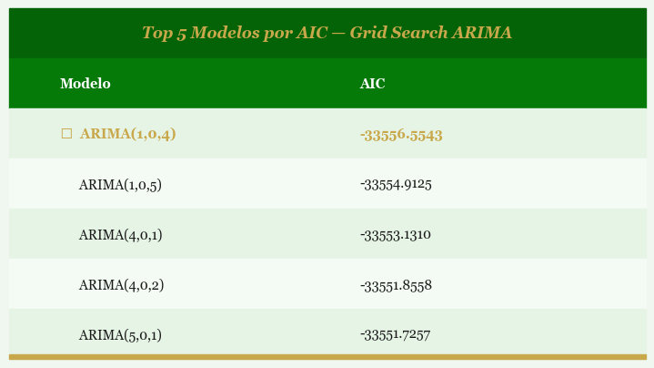

```python
import numpy as np
import pandas as pd
from statsmodels.tsa.arima.model import ARIMA

np.random.seed(42)

# Espacio de búsqueda
p_values = list(range(6))  # 0-5
d_fixed  = 0               # d=0 fijo (retornos estacionarios)
q_values = list(range(6))  # 0-5
n_iter   = 30

# Muestreo aleatorio de combinaciones
search_grid = pd.DataFrame({
    'p': np.random.choice(p_values, n_iter, replace=True),
    'd': 0,
    'q': np.random.choice(q_values, n_iter, replace=True),
})

# Eliminar combinaciones triviales p=0, q=0
search_grid = search_grid[~((search_grid['p'] == 0) & (search_grid['q'] == 0))]

# Asegurar al menos 25 filas únicas
while len(search_grid) < 25:
    extra = pd.DataFrame({
        'p': np.random.choice(p_values, 5, replace=True),
        'd': 0,
        'q': np.random.choice(q_values, 5, replace=True),
    })
    extra = extra[~((extra['p'] == 0) & (extra['q'] == 0))]
    search_grid = pd.concat([search_grid, extra], ignore_index=True)

search_grid = search_grid.drop_duplicates().iloc[:25].reset_index(drop=True)
print(f"Combinaciones únicas a evaluar: {len(search_grid)}\n")

# Función de evaluación
def evaluate_arima(p, d, q, serie):
    try:
        fit = ARIMA(serie, order=(p, d, q)).fit()
        return fit.aic
    except:
        return np.inf  # Penaliza modelos que no convergen

# Ejecutar Random Search
search_grid['AIC'] = search_grid.apply(
    lambda row: evaluate_arima(int(row['p']), int(row['d']), int(row['q']), returns_clean),
    axis=1
)

# Ordenar por AIC ascendente
results = search_grid.sort_values('AIC').reset_index(drop=True)

print("Top 5 modelos por AIC:")
import matplotlib.pyplot as plt

plt.rcParams['font.family'] = 'Georgia'

C_HEADER = '#046307'
C_SUB    = '#057a09'
C_ROW1   = '#e6f4e6'
C_ROW2   = '#f4fbf4'
C_GOLD   = '#c9a84c'
C_TEXT   = '#1a1a1a'
C_WHITE  = 'white'
BG       = '#f0f7f0'

# ── Datos ─────────────────────────────────────────────────────────────────────
results = search_grid.sort_values('AIC').reset_index(drop=True)
top5    = results.head(5)

columnas = ['p', 'd', 'q', 'AIC']
filas    = [(f"ARIMA({int(r.p)},{int(r.d)},{int(r.q)})",
             f"{r.AIC:.4f}") for _, r in top5.iterrows()]

# ── Dimensiones ───────────────────────────────────────────────────────────────
n_filas    = len(filas) + 2          # título + subencabezado + datos
row_h      = 0.055
fig_h      = n_filas * row_h * 10
fig, ax    = plt.subplots(figsize=(7, fig_h), facecolor=BG)
ax.set_facecolor(BG)
ax.axis('off')
ax.set_xlim(0, 1)
ax.set_ylim(0, 1)

rh    = 1 / n_filas
x_izq = 0.08
x_der = 0.55

def draw_row(ax, row_idx, bg, texto_izq, texto_der='',
             color_izq=None, color_der=None,
             bold_izq=False, bold_der=False,
             fontsize=10.5, center_izq=False):
    y_bottom = 1 - (row_idx + 1) * rh
    ax.add_patch(plt.Rectangle((0, y_bottom), 1, rh,
                 color=bg, transform=ax.transAxes, clip_on=False))
    ax.text(0.5 if center_izq else x_izq,
            y_bottom + rh / 2, texto_izq,
            transform=ax.transAxes,
            ha='center' if center_izq else 'left', va='center',
            fontsize=fontsize, color=color_izq or C_TEXT,
            fontweight='bold' if bold_izq else 'normal',
            fontstyle='italic' if center_izq else 'normal')
    if texto_der:
        ax.text(x_der, y_bottom + rh / 2, texto_der,
                transform=ax.transAxes, ha='left', va='center',
                fontsize=fontsize, color=color_der or C_TEXT,
                fontweight='bold' if bold_der else 'normal')

# Título
draw_row(ax, 0, C_HEADER,
         'Top 5 Modelos por AIC — Grid Search ARIMA',
         color_izq=C_GOLD, bold_izq=True,
         fontsize=12.5, center_izq=True)

# Subencabezado
draw_row(ax, 1, C_SUB,
         'Modelo', 'AIC',
         color_izq=C_WHITE, color_der=C_WHITE,
         bold_izq=True, bold_der=True)

# Filas de datos
for idx, (modelo, aic) in enumerate(filas):
    bg      = C_ROW1 if idx % 2 == 0 else C_ROW2
    es_best = idx == 0
    draw_row(ax, idx + 2, bg,
             ('★  ' if es_best else '      ') + modelo, aic,
             color_izq=C_GOLD if es_best else C_TEXT,
             color_der=C_GOLD if es_best else C_TEXT,
             bold_izq=es_best, bold_der=es_best)

# Línea dorada inferior
ax.add_patch(plt.Rectangle((0, 0), 1, 0.012,
             color=C_GOLD, transform=ax.transAxes, clip_on=False))

plt.tight_layout(pad=0)
plt.show()
```

### Resultado del Random Search

```python
# Extraer los mejores hiperparámetros
best_p   = int(results['p'].iloc[0])
best_d   = int(results['d'].iloc[0])
best_q   = int(results['q'].iloc[0])
best_aic = results['AIC'].iloc[0]

print(f"Mejor modelo encontrado: ARIMA({best_p}, {best_d}, {best_q})")
print(f"AIC del mejor modelo:    {best_aic:.4f}")
```

```
Mejor modelo encontrado: ARIMA(1, 0, 4)
AIC del mejor modelo:    -33556.5543
```

El modelo ARIMA(1,0,4) sugiere que los retornos de MSFT presentan una dinámica mixta: dependencia autorregresiva de orden 1 y efectos de media móvil de orden 4, lo que es coherente con la hipótesis de mercados semi-eficientes donde la información se incorpora gradualmente en el precio durante los primeros días hábiles tras un choque.

## Ajuste del Mejor Modelo ARIMA

Con los hiperparámetros óptimos identificados mediante Random Search, se procede al ajuste definitivo del modelo sobre la totalidad de la serie de retornos.

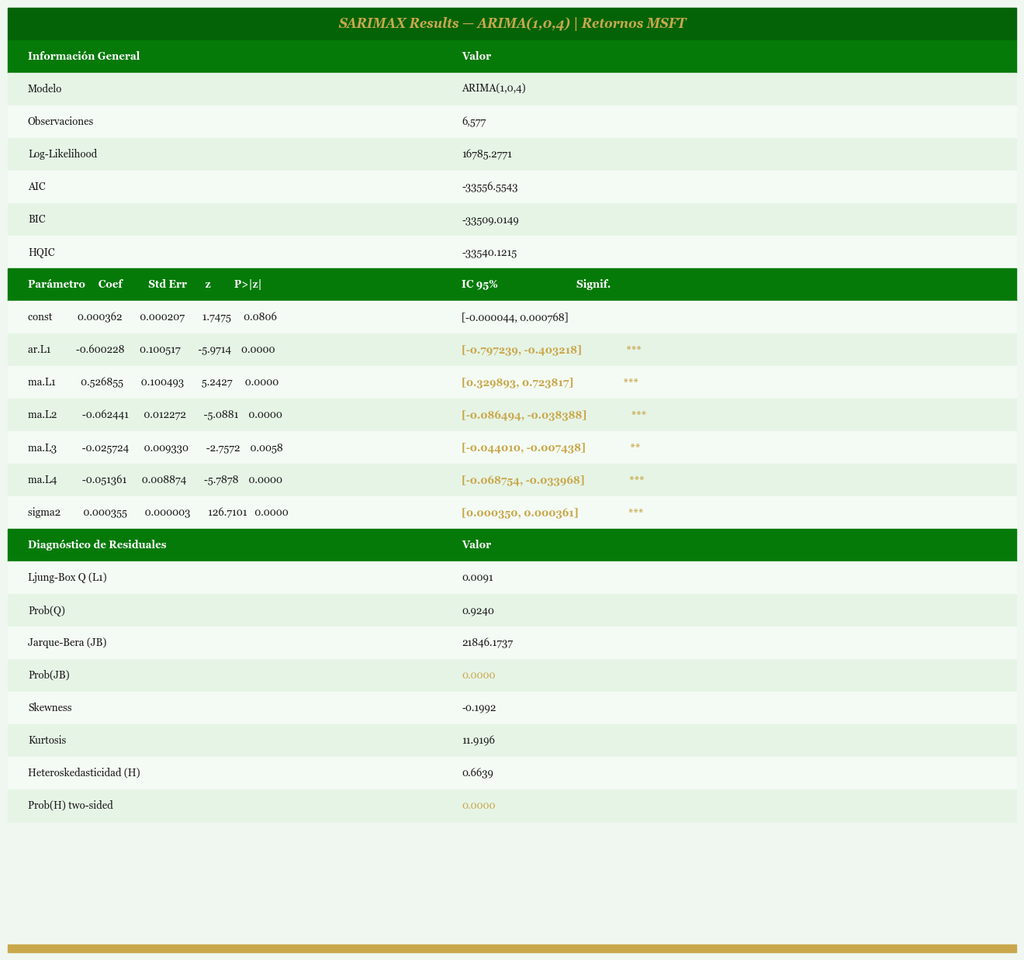

```python
from statsmodels.tsa.arima.model import ARIMA

# Ajuste del modelo con los mejores parámetros
best_model = ARIMA(returns_clean, order=(best_p, best_d, best_q)).fit()

# Resumen del modelo
import matplotlib.pyplot as plt
from statsmodels.tsa.arima.model import ARIMA

# ── Fuente elegante ───────────────────────────────────────────────────────────
plt.rcParams['font.family'] = 'Georgia'

# ── Colores esmeralda + gold ──────────────────────────────────────────────────
C_HEADER = '#046307'
C_SUB    = '#057a09'
C_ROW1   = '#e6f4e6'
C_ROW2   = '#f4fbf4'
C_GOLD   = '#c9a84c'
C_TEXT   = '#1a1a1a'
C_WHITE  = 'white'
BG       = '#f0f7f0'

# ── Ajuste del modelo ─────────────────────────────────────────────────────────
best_model = ARIMA(returns_clean, order=(best_p, best_d, best_q)).fit()

# ── Extraer resultados ────────────────────────────────────────────────────────
params   = best_model.params
bse      = best_model.bse
tvalues  = best_model.tvalues
pvalues  = best_model.pvalues
ci       = best_model.conf_int()

# ── Filas: info general ───────────────────────────────────────────────────────
info_filas = [
    ('Modelo',            f'ARIMA({best_p},{best_d},{best_q})'),
    ('Observaciones',     f'{int(best_model.nobs):,}'),
    ('Log-Likelihood',    f'{best_model.llf:.4f}'),
    ('AIC',               f'{best_model.aic:.4f}'),
    ('BIC',               f'{best_model.bic:.4f}'),
    ('HQIC',              f'{best_model.hqic:.4f}'),
]

# ── Filas: coeficientes ───────────────────────────────────────────────────────
coef_filas = []
for name in params.index:
    sig = '***' if pvalues[name] < 0.001 else \
          '**'  if pvalues[name] < 0.01  else \
          '*'   if pvalues[name] < 0.05  else ''
    coef_filas.append((
        name,
        f'{params[name]:.6f}',
        f'{bse[name]:.6f}',
        f'{tvalues[name]:.4f}',
        f'{pvalues[name]:.4f}',
        f'[{ci.iloc[params.index.get_loc(name), 0]:.6f}, '
        f'{ci.iloc[params.index.get_loc(name), 1]:.6f}]',
        sig
    ))

# ── Diagnóstico ───────────────────────────────────────────────────────────────
lb_pval  = best_model.test_serial_correlation('ljungbox', lags=1)[0][1, 0]
jb_vals  = best_model.test_normality('jarquebera')[0]
het_vals = best_model.test_heteroskedasticity('breakvar')[0]

diag_filas = [
    ('Ljung-Box Q (L1)',        f'{best_model.test_serial_correlation("ljungbox", lags=1)[0][0,0]:.4f}'),
    ('Prob(Q)',                 f'{lb_pval:.4f}'),
    ('Jarque-Bera (JB)',        f'{jb_vals[0]:.4f}'),
    ('Prob(JB)',                f'{jb_vals[1]:.4f}'),
    ('Skewness',                f'{jb_vals[2]:.4f}'),
    ('Kurtosis',                f'{jb_vals[3]:.4f}'),
    ('Heteroskedasticidad (H)', f'{het_vals[0]:.4f}'),
    ('Prob(H) two-sided',       f'{het_vals[1]:.4f}'),
]

# ── Dimensiones dinámicas ─────────────────────────────────────────────────────
n_total = 2 + len(info_filas) + 2 + 1 + len(coef_filas) + 2 + len(diag_filas) + 1
rh      = 1 / n_total
fig_h   = max(10, n_total * 0.42)

fig, ax = plt.subplots(figsize=(13, fig_h), facecolor=BG)
ax.set_facecolor(BG)
ax.axis('off')
ax.set_xlim(0, 1)
ax.set_ylim(0, 1)

x_izq = 0.02
x_der = 0.45

def draw_row(ax, row_idx, bg, texto_izq, texto_der='',
             color_izq=None, color_der=None,
             bold_izq=False, bold_der=False,
             fontsize=9.5, center_izq=False):
    y_bottom = 1 - (row_idx + 1) * rh
    ax.add_patch(plt.Rectangle((0, y_bottom), 1, rh,
                 color=bg, transform=ax.transAxes, clip_on=False))
    ax.text(0.5 if center_izq else x_izq,
            y_bottom + rh / 2, texto_izq,
            transform=ax.transAxes,
            ha='center' if center_izq else 'left', va='center',
            fontsize=fontsize, color=color_izq or C_TEXT,
            fontweight='bold' if bold_izq else 'normal',
            fontstyle='italic' if center_izq else 'normal')
    if texto_der:
        ax.text(x_der, y_bottom + rh / 2, texto_der,
                transform=ax.transAxes, ha='left', va='center',
                fontsize=fontsize, color=color_der or C_TEXT,
                fontweight='bold' if bold_der else 'normal')

row = 0

# ── TÍTULO ────────────────────────────────────────────────────────────────────
draw_row(ax, row, C_HEADER,
         f'SARIMAX Results — ARIMA({best_p},{best_d},{best_q}) | Retornos MSFT',
         color_izq=C_GOLD, bold_izq=True, fontsize=12, center_izq=True)
row += 1

# ── ENCABEZADO INFO GENERAL ───────────────────────────────────────────────────
draw_row(ax, row, C_SUB, 'Información General', 'Valor',
         color_izq=C_WHITE, color_der=C_WHITE, bold_izq=True, bold_der=True)
row += 1

for etiqueta, valor in info_filas:
    bg = C_ROW1 if row % 2 == 0 else C_ROW2
    draw_row(ax, row, bg, etiqueta, valor)
    row += 1

# ── ENCABEZADO COEFICIENTES ───────────────────────────────────────────────────
draw_row(ax, row, C_SUB,
         'Parámetro     Coef          Std Err       z         P>|z|',
         'IC 95%                              Signif.',
         color_izq=C_WHITE, color_der=C_WHITE, bold_izq=True, bold_der=True)
row += 1

for (name, coef, std, z, pval, ic, sig) in coef_filas:
    bg        = C_ROW1 if row % 2 == 0 else C_ROW2
    p_color   = C_GOLD  if float(pval) < 0.05 else C_TEXT
    texto_izq = f'{name:<14} {coef:<14} {std:<14} {z:<10} {pval}'
    texto_der = f'{ic:<38} {sig}'
    draw_row(ax, row, bg, texto_izq, texto_der,
             color_der=p_color, bold_der=float(pval) < 0.05)
    row += 1

# ── ENCABEZADO DIAGNÓSTICO ────────────────────────────────────────────────────
draw_row(ax, row, C_SUB, 'Diagnóstico de Residuales', 'Valor',
         color_izq=C_WHITE, color_der=C_WHITE, bold_izq=True, bold_der=True)
row += 1

for etiqueta, valor in diag_filas:
    bg       = C_ROW1 if row % 2 == 0 else C_ROW2
    es_prob  = 'Prob' in etiqueta
    d_color  = C_GOLD if (es_prob and float(valor) < 0.05) else C_TEXT
    draw_row(ax, row, bg, etiqueta, valor, color_der=d_color)
    row += 1

# ── LÍNEA DORADA INFERIOR ─────────────────────────────────────────────────────
ax.add_patch(plt.Rectangle((0, 0), 1, 0.008,
             color=C_GOLD, transform=ax.transAxes, clip_on=False))

plt.tight_layout(pad=0)
plt.show()
```